# Simulation Exercise

Marque Staneluis

April 28, 2018

## Overview

The purpose of this project is to investigate the exponential distribution in R and compare it with the Central Limit Theorem. The exponential distribution can be simulated in R with rexp(n, lambda) where lambda is the rate parameter. The mean of exponential distribution is 1/lambda and the standard deviation is also 1/lambda. Set lambda = 0.2 for all of the simulations. This investigates the distribution of averages of 40 exponentials over 1,000 simulations.

## Part 1: Simulations

Set the simulation variables lambda, n, and seed.

```r
ECHO=TRUE
set.seed(1337)
lambda = 0.2
n = 40
```

Run Simulations with variables

```r
mns = NULL
for (i in 1 : 1000) mns = c(mns, mean(rexp(n, lambda)))
```

## Part 2: Sample Mean versus Theoretical Mean

#### Sample Mean

Calculating the mean from the simulations with give the sample mean.

```r
sampMean <-mean(mns)
sampMean
```

```
## [1] 5.055995
```

#### Theoretical Mean

The theoretical mean of an exponential distribution is lambda^-1.

```r
theoMean <- lambda^-1
theoMean
```

```
## [1] 5
```

#### Comparison

There is only a slight difference between the simulations sample mean and the exponential distribution theoretical mean.

```r
abs(mean(mns)-lambda^-1)
```

```
## [1] 0.05599526
```

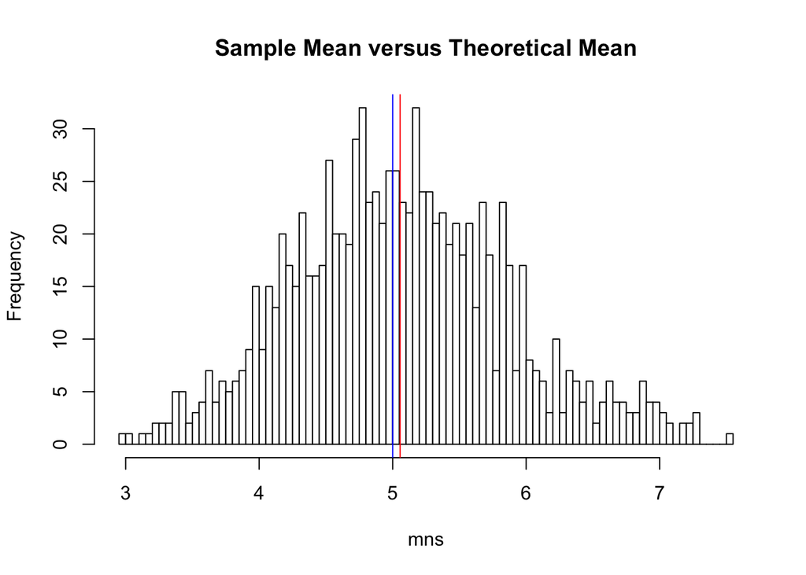

```r
hist(mns, main = "Sample Mean versus Theoretical Mean", col = "white", breaks = 100)
abline(v = sampMean, col = "red")
abline(v = theoMean, col = "blue")
```

## Part 3: Sample Variance versus Theoretical Variance

#### Sample Variance

Calculating the variance from the simulation means with give the sample variance.

```r
sampVar <- var(mns)
sampVar
```

```
## [1] 0.6543703
```

#### Theoretical Variance

```r
theoVar <- (lambda * sqrt(n))^-2
theoVar
```

```
## [1] 0.625
```

#### Comparison

There is only a slight difference between the simulations sample variance and the exponential distribution theoretical variance.

```r
abs(var(mns)-(lambda * sqrt(n))^-2)
```

```
## [1] 0.0293703
```

## Part 4: Distribution

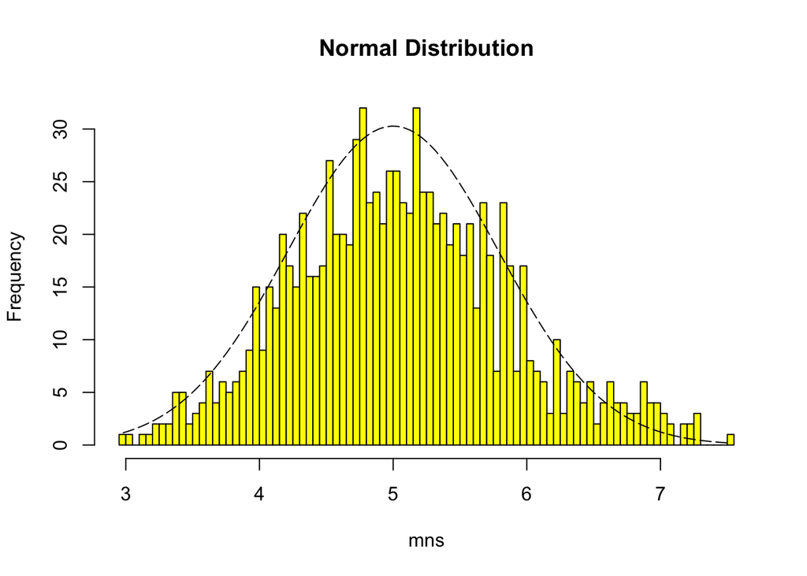

```r
hist(mns, main = "Normal Distribution", col = "yellow", breaks = 100)
xfit <- seq(min(mns), max(mns), length = 100)
yfit <- dnorm(xfit, mean = 1/lambda, sd = (1/lambda)/sqrt(n))
lines(xfit, yfit*60, lty = 5)
```